# Tidymodels Project

Ikechukwu Fredrick Okorie

2022-09-07

# **TIDYMODELS PROJECT**

For this project we will consider the consumer complaints data from [Consumer Complaint Database](https://www.consumerfinance.gov/data-research/consumer-complaints/) (CFPB). The CFPB is an independent agency of the United States government that promotes transparency and protects consumers by providing information needed to make decisions when choosing financial institutions including banking institutions, lenders, mortgage services, credit unions, securities firms, foreclosure services, and debt collectors. One of the purposes of the agency is to receive and process complaints and questions about consumer financial products and services.

When a complaint is submitted by a consumer, the CFPB has to determine which category the complaint falls in (e.g. “Mortgage”, “Student loan”, etc).In this project, the goal will be to use the skills you have learned about in this course to build a classification algorithm to classify consumer complaints into one of four categories: “Credit card or prepaid card”, “Mortgage”, “Student loan”, or “Vehicle loan or lease”.

## **LOAD THE REQUIRED LIBRARIES**

```r
library(tidymodels)
library(tidyverse)
library(visdat)
library(skimr)
library(tidytext)
library(tidylo)
library(textrecipes)
library(themis)
library(doParallel)
library(stopwords)
```

## **LOAD OUR DATA**

```r
## Load the data
train_data <- read_csv("data_complaints_train.csv")
test_data <- read.csv("data_complaints_test.csv")
```

## **EXPLORE THE TRAIN DATA**

```r
## Check dimension of your data
dim(train_data)
```

```
## [1] 90975     6
```

```r
dim(test_data)
```

```
## [1] 20  6
```

```r
## view the train data
train_data %>% glimpse()
```

```
## Rows: 90,975
## Columns: 6
## $ Product                        <chr> "Credit card or prepaid card", "Mortgag…
## $ `Consumer complaint narrative` <chr> "I initially in writing to Chase Bank i…
## $ Company                        <chr> "JPMORGAN CHASE & CO.", "Ditech Financi…
## $ State                          <chr> "CT", "GA", "IN", "MI", "MI", "FL", "WA…
## $ `ZIP code`                     <chr> "064XX", "None", "463XX", "490XX", "480…
## $ `Submitted via`                <chr> "Web", "Web", "Web", "Web", "Web", "Web…
```

```r
## Inspect the target variable
table(train_data$Product)
```

```
##
## Credit card or prepaid card                    Mortgage
##                       38294                       30957
##                Student loan       Vehicle loan or lease
##                       12485                        9239
```

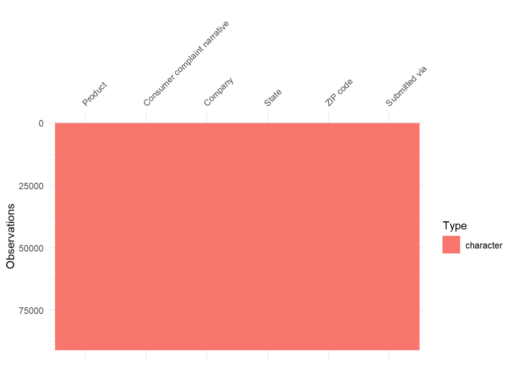

```r
## visualize data structure
vis_dat(train_data)
```

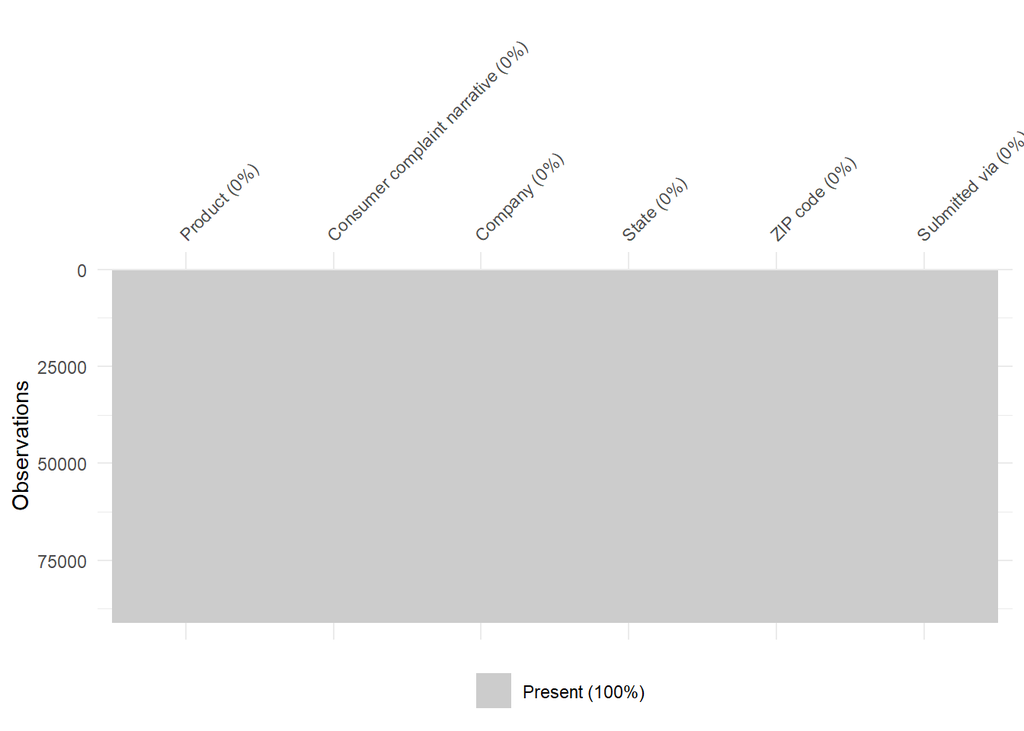

```r
## visualize missing values
vis_miss(train_data)
```

We can see from the plot of the data structure and that of missing values of our training dataset that there are no missing values.

Next, as part of our data wrangling process we want to know the distinct values in some of our independent variables

```r
## Number of unique values in State, Company, and Submitted columns
train_data %>% select(State) %>% n_distinct()
```

```
## [1] 62
```

```r
train_data %>% select(Company) %>% n_distinct()
```

```
## [1] 1497
```

```r
train_data %>% select(`Submitted via`) %>% n_distinct()
```

```
## [1] 1
```

Lets look at Consumer Complaints Narrative column for more context

```r
## Lets look at the consumer complaints narrative column
head(train_data$`Consumer complaint narrative`)
```

```
## [1] "I initially in writing to Chase Bank in late XXXX about a charge that was unauthorized on XXXX from XXXX in the amount of {$790.00} after many letters and complaints they still did not do anything yet in XXXX they closed my original account and reissued a new account and sent me a letter ind…
## [2] "My ex husband and myself had a mobile home ( Home Mortgage ) with XXXX XXXX back in XX/XX/XXXX. I went through a horrible divorce as my husband was using drugs and failing to pay the bills which led to my having to divorce him. The Mortgage was in both of our names. We only had the Mortgage …
## [3] "I was a student at XXXX XXXX from XX/XX/XXXX-XX/XX/XXXX. I accumulated XXXX of debt in student loans. This school flat out lied to me. I was under the assumption it would have been less than half of that since I had a lot of credits that transferred, not to mention this school promised me jo…
## [4] "It has come to my attention the CITI group is actively attempting to interfere with rights guaranteed by the Constitution ( 2nd Amendment ) by manipulating or denying service to certain entities or transactions that are protected by the Constitution. I do not expect CITI group, or any other …
## [5] "This banks new firearm policies run counter to laws and regulations passed by Congress, and they infringe and discriminate against an individuals Second Amendment rights. Such policies, should not be endorsed by our federal government, which instead should do business with companies that res…
## [6] "I only use my walmart store card to keep from having it cancelled. My sons a college student had his card cancelled for non use. I made a small purchase in XX/XX/XXXX and paid it off. Made another small purchase in XX/XX/XXXX and thought i paid it off online via wlamart.com but that seemed n…
```

The complaint narratives contain many series of “x”’s meant to protect personally Identifiable information (PII)

Next we convert all the variables to factor, except the CCN column

```r
train_data <- train_data %>%
  mutate(across(c(Product, Company, State, `ZIP code`, `Submitted via`), as.factor))

## Confirm change
train_data %>% glimpse()
```

```
## Rows: 90,975
## Columns: 6
## $ Product                        <fct> Credit card or prepaid card, Mortgage, …
## $ `Consumer complaint narrative` <chr> "I initially in writing to Chase Bank i…
## $ Company                        <fct> "JPMORGAN CHASE & CO.", "Ditech Financi…
## $ State                          <fct> CT, GA, IN, MI, MI, FL, WA, CA, CA, VA,…
## $ `ZIP code`                     <fct> 064XX, None, 463XX, 490XX, 480XX, 331XX…
## $ `Submitted via`                <fct> Web, Web, Web, Web, Web, Web, Web, Web,…
```

```r
## Obtain summary statistics of our training set
skim(train_data)
```

Data summary

| Name | train_data |
| --- | --- |
| Number of rows | 90975 |
| Number of columns | 6 |
| _______________________ |  |
| Column type frequency: |  |
| character | 1 |
| factor | 5 |
| ________________________ |  |
| Group variables | None |

**Variable type: character**

| skim_variable | n_missing | complete_rate | min | max | empty | n_unique | whitespace |
| --- | --- | --- | --- | --- | --- | --- | --- |
| Consumer complaint narrative | 0 | 1 | 12 | 32317 | 0 | 90240 | 0 |

**Variable type: factor**

| skim_variable | n_missing | complete_rate | ordered | n_unique | top_counts |
| --- | --- | --- | --- | --- | --- |
| Product | 0 | 1 | FALSE | 4 | Cre: 38294, Mor: 30957, Stu: 12485, Veh: 9239 |
| Company | 0 | 1 | FALSE | 1497 | CIT: 6520, CAP: 5808, Nav: 5330, JPM: 4978 |
| State | 0 | 1 | FALSE | 62 | CA: 13552, FL: 8381, TX: 7114, NY: 5916 |
| ZIP code | 0 | 1 | FALSE | 5484 | Non: 21892, 300: 1197, 750: 926, 606: 853 |
| Submitted via | 0 | 1 | FALSE | 1 | Web: 90975 |

Next we visualize our target variable

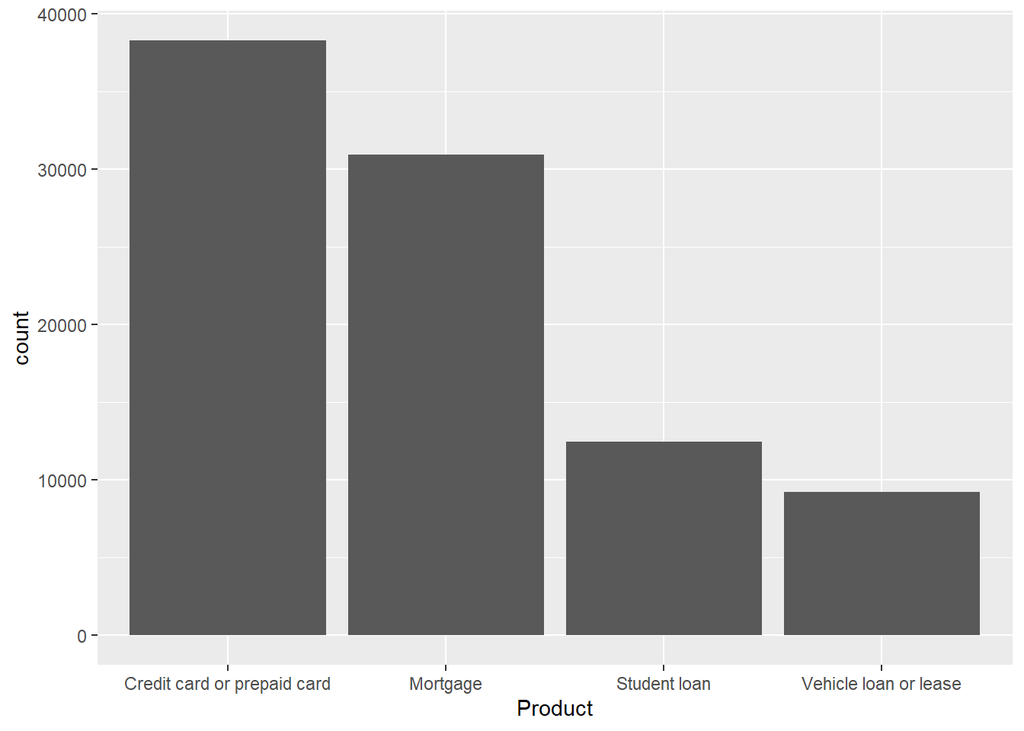

```r
## Visualize target variable
train_data %>% ggplot(aes(Product)) + geom_bar()
```

There are more complaints related to “Credit card or prepaid card” than “Student loan” and “Vehicle loan or lease” combined. “Mortgage” is second.

## **A LOOK AT THE CONSUMER COMPLAINTS NARRATIVE TEXT**

Here we look at the text in the CCN column to make better sense of it and how it relates to our target variable (Product)

```r
narrative_count <- train_data %>%
  unnest_tokens(word, `Consumer complaint narrative`) %>%
  count(Product, word, sort = TRUE) %>% bind_log_odds(Product, word, n)

narrative_count %>% head()
```

```
## # A tibble: 6 × 4
##   Product                     word       n log_odds_weighted
##   <fct>                       <chr>  <int>             <dbl>
## 1 Mortgage                    xxxx  447683            24.7
## 2 Mortgage                    the   441533             0.216
## 3 Credit card or prepaid card the   399071             2.13
## 4 Credit card or prepaid card i     369514            27.1
## 5 Mortgage                    to    358103             3.85
## 6 Credit card or prepaid card xxxx  337973           -27.9
```

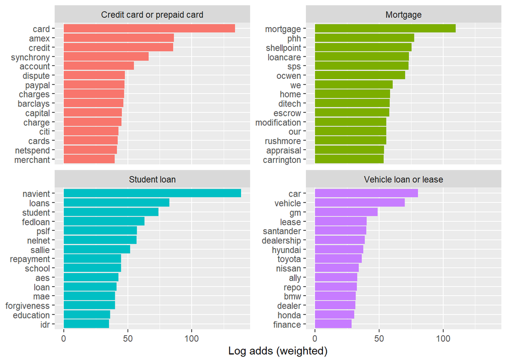

```r
## Visualize narrative count by product
narrative_count %>% group_by(Product) %>%
  slice_max(log_odds_weighted, n =15) %>%
  ungroup() %>% ggplot(aes(log_odds_weighted, fct_reorder(word,log_odds_weighted),
                           fill = Product)) + geom_col(show.legend = FALSE) +
  facet_wrap(vars(Product), scales = "free_y") +
  labs(x = "Log adds (weighted)", y = NULL)
```

## **SPLIT OUR TRAINING DATASET**

```r
set.seed(1234)
first_split <- initial_split(train_data, strata = Product) ## split 3/4 ratio
first_train <- training(first_split)
first_test <- testing(first_split)

## check dimension of our split data
first_train %>% nrow()
```

```
## [1] 68229
```

```r
first_test %>% nrow()
```

```
## [1] 22746
```

## **CREATE FOLDS FOR CROSS VALIDATION**

Here we randomly split of *first_train* data into v groups of roughly equal size

```r
## Create folds
target_fold <- vfold_cv(first_train, strata = Product)

target_fold
```

```
## #  10-fold cross-validation using stratification
## # A tibble: 10 × 2
##    splits               id
##    <list>               <chr>
##  1 <split [61405/6824]> Fold01
##  2 <split [61405/6824]> Fold02
##  3 <split [61405/6824]> Fold03
##  4 <split [61406/6823]> Fold04
##  5 <split [61406/6823]> Fold05
##  6 <split [61406/6823]> Fold06
##  7 <split [61406/6823]> Fold07
##  8 <split [61407/6822]> Fold08
##  9 <split [61407/6822]> Fold09
## 10 <split [61408/6821]> Fold10
```

## **CREATE RECIPES AND FEATURE ENGINEERING**

```r
my_rec <- recipe(Product ~ Company + `ZIP code` + State + `Consumer complaint narrative`,
                 data = first_train) %>%
  # mitigate imbalance by making levels equal
  themis::step_downsample(Product) %>%
  # convert character predictor (Narrative) into a token variable
  step_tokenize(`Consumer complaint narrative`) %>%
  # remove stop words
  step_stopwords(`Consumer complaint narrative`) %>%
  # stem tokens
  step_stem(`Consumer complaint narrative`) %>%
  # keep only top 250 max_tokens
  textrecipes::step_tokenfilter(`Consumer complaint narrative`, max_tokens = 250) %>%
  # "step_tfidf creates a specification of a recipe step that will convert
  #  a token variable into multiple variables containing the term
  #  frequency-inverse document frequency of tokens."
  textrecipes::step_tfidf(`Consumer complaint narrative`) %>%
  # convert factors to numeric (dummy)
  step_dummy(all_nominal_predictors())

my_rec
```

```
## Recipe
##
## Inputs:
##
##       role #variables
##    outcome          1
##  predictor          4
##
## Operations:
##
## Down-sampling based on Product
## Tokenization for `Consumer complaint narrative`
## Stop word removal for `Consumer complaint narrative`
## Stemming for `Consumer complaint narrative`
## Text filtering for `Consumer complaint narrative`
## Term frequency-inverse document frequency with `Consumer complaint narrative`
## Dummy variables from all_nominal_predictors()
```

## **CREATE MODEL**

We will use a Lasso model, since we have a few words or tokens the CCN column that influence the target variable (Product). Lasso will drop ‘insignificant’ predictors

```r
model <- parsnip::multinom_reg(penalty = tune(), mixture = 1) %>%
  set_mode("classification") %>%
  set_engine("glmnet")

model
```

```
## Multinomial Regression Model Specification (classification)
##
## Main Arguments:
##   penalty = tune()
##   mixture = 1
##
## Computational engine: glmnet
```

## **CREATE WORKFLOW**

```r
rec_wf <- workflow(my_rec, model)

rec_wf
```

```
## ══ Workflow ════════════════════════════════════════════════════════════════════
## Preprocessor: Recipe
## Model: multinom_reg()
##
## ── Preprocessor ────────────────────────────────────────────────────────────────
## 7 Recipe Steps
##
## • step_downsample()
## • step_tokenize()
## • step_stopwords()
## • step_stem()
## • step_tokenfilter()
## • step_tfidf()
## • step_dummy()
##
## ── Model ───────────────────────────────────────────────────────────────────────
## Multinomial Regression Model Specification (classification)
##
## Main Arguments:
##   penalty = tune()
##   mixture = 1
##
## Computational engine: glmnet
```

## **CREATE AND REVIEW TUNING PARAMETERS**

```r
# create a grid to tune the 'penalty' parameter
model_grid <- grid_regular(penalty(range(c(-5,0))), levels =20)

registerDoParallel()

set.seed(289)

target_tune <- tune_grid(rec_wf, target_fold, grid = model_grid)

target_tune
```

```
## # Tuning results
## # 10-fold cross-validation using stratification
## # A tibble: 10 × 4
##    splits               id     .metrics          .notes
##    <list>               <chr>  <list>            <list>
##  1 <split [61405/6824]> Fold01 <tibble [40 × 5]> <tibble [0 × 3]>
##  2 <split [61405/6824]> Fold02 <tibble [40 × 5]> <tibble [1 × 3]>
##  3 <split [61405/6824]> Fold03 <tibble [40 × 5]> <tibble [1 × 3]>
##  4 <split [61406/6823]> Fold04 <tibble [40 × 5]> <tibble [1 × 3]>
##  5 <split [61406/6823]> Fold05 <tibble [40 × 5]> <tibble [1 × 3]>
##  6 <split [61406/6823]> Fold06 <tibble [40 × 5]> <tibble [1 × 3]>
##  7 <split [61406/6823]> Fold07 <tibble [40 × 5]> <tibble [0 × 3]>
##  8 <split [61407/6822]> Fold08 <tibble [40 × 5]> <tibble [1 × 3]>
##  9 <split [61407/6822]> Fold09 <tibble [40 × 5]> <tibble [1 × 3]>
## 10 <split [61408/6821]> Fold10 <tibble [40 × 5]> <tibble [1 × 3]>
##
## There were issues with some computations:
##
##   - Warning(s) x8: from glmnet C++ code (error code -42); Convergence for 42th lambd...
##
## Run `show_notes(.Last.tune.result)` for more information.
```

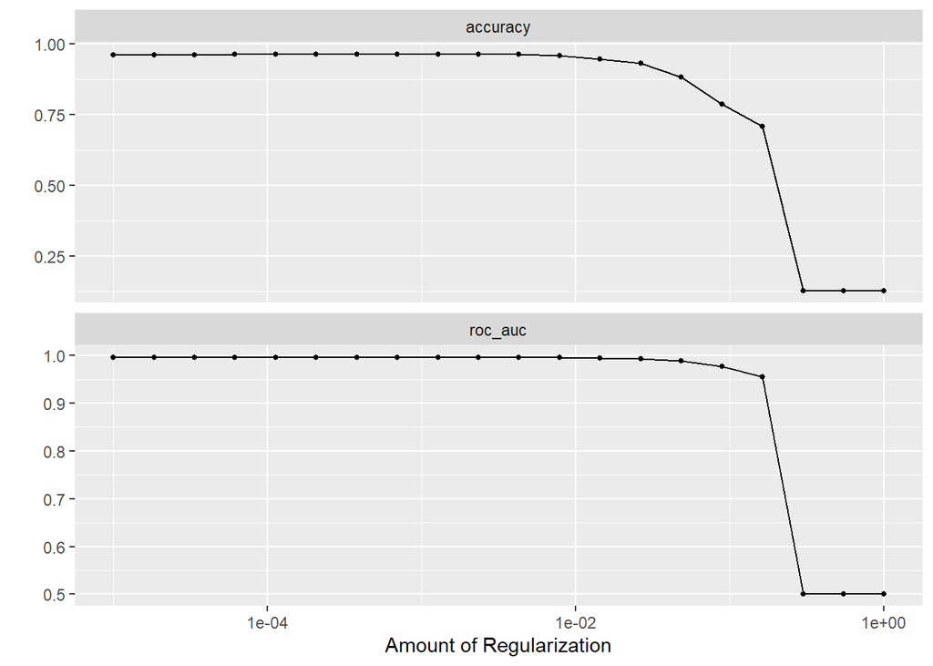

```r
## plot results
autoplot(target_tune)
```

```r
# display best sets of hyperparameters based on accuracy and area under the curve
show_best(target_tune, metric = "accuracy")
```

```
## # A tibble: 5 × 7
##    penalty .metric  .estimator  mean     n  std_err .config
##      <dbl> <chr>    <chr>      <dbl> <int>    <dbl> <chr>
## 1 0.00127  accuracy multiclass 0.964    10 0.00137  Preprocessor1_Model09
## 2 0.000695 accuracy multiclass 0.964    10 0.00123  Preprocessor1_Model08
## 3 0.00234  accuracy multiclass 0.963    10 0.00115  Preprocessor1_Model10
## 4 0.000379 accuracy multiclass 0.963    10 0.00110  Preprocessor1_Model07
## 5 0.000207 accuracy multiclass 0.963    10 0.000788 Preprocessor1_Model06
```

```r
show_best(target_tune, metric = "roc_auc")
```

```
## # A tibble: 5 × 7
##    penalty .metric .estimator  mean     n  std_err .config
##      <dbl> <chr>   <chr>      <dbl> <int>    <dbl> <chr>
## 1 0.000695 roc_auc hand_till  0.997    10 0.000290 Preprocessor1_Model08
## 2 0.000379 roc_auc hand_till  0.997    10 0.000286 Preprocessor1_Model07
## 3 0.00127  roc_auc hand_till  0.997    10 0.000278 Preprocessor1_Model09
## 4 0.000207 roc_auc hand_till  0.996    10 0.000264 Preprocessor1_Model06
## 5 0.00234  roc_auc hand_till  0.996    10 0.000246 Preprocessor1_Model10
```

```r
## Select best model based on some metrics
select_best(target_tune, metric = "accuracy")
```

```
## # A tibble: 1 × 2
##   penalty .config
##     <dbl> <chr>
## 1 0.00127 Preprocessor1_Model09
```

```r
select_best(target_tune, metric = "roc_auc")
```

```
## # A tibble: 1 × 2
##    penalty .config
##      <dbl> <chr>
## 1 0.000695 Preprocessor1_Model08
```

Although we have found the **‘best’** set of hyperparmanters using select_best(), we can get a simpler model by selecting a model within one standard error of the best model using select_by_one_std_err() after sorting the penalties in descending order.

```r
## select the best performing hyperparameter based on one standard error
best_hyper <- target_tune %>%
  select_by_one_std_err(metric = "roc_auc", desc(penalty))

best_hyper
```

```
## # A tibble: 1 × 9
##   penalty .metric .estimator  mean     n  std_err .config           .best .bound
##     <dbl> <chr>   <chr>      <dbl> <int>    <dbl> <chr>             <dbl>  <dbl>
## 1 0.00428 roc_auc hand_till  0.996    10 0.000198 Preprocessor1_Mo… 0.997  0.996
```

```r
## determine the best model using finalize_workflow()
final_model <- rec_wf %>%
  finalize_workflow(best_hyper) %>% last_fit(first_split)

final_model
```

```
## # Resampling results
## # Manual resampling
## # A tibble: 1 × 6
##   splits                id               .metrics .notes   .predict…¹ .workflow
##   <list>                <chr>            <list>   <list>   <list>     <list>
## 1 <split [68229/22746]> train/test split <tibble> <tibble> <tibble>   <workflow>
## # … with abbreviated variable name ¹.predictions
```

## **EVALUATE MODEL PERFORMANCE**

As this is a classification model our metrics will be *accuracy* and *roc (Area under the curve)*

```r
# extract statistics
collect_metrics(final_model)
```

```
## # A tibble: 2 × 4
##   .metric  .estimator .estimate .config
##   <chr>    <chr>          <dbl> <chr>
## 1 accuracy multiclass     0.967 Preprocessor1_Model1
## 2 roc_auc  hand_till      0.997 Preprocessor1_Model1
```

```r
# review confusion matrix
confusion_matrix <- collect_predictions(final_model) %>%
  conf_mat(Product, .pred_class)

confusion_matrix
```

```
##                              Truth
## Prediction                    Credit card or prepaid card Mortgage Student loan
##   Credit card or prepaid card                        9323      169           27
##   Mortgage                                             53     7414           14
##   Student loan                                         19       10         3045
##   Vehicle loan or lease                               179      147           36
##                              Truth
## Prediction                    Vehicle loan or lease
##   Credit card or prepaid card                    75
##   Mortgage                                       24
##   Student loan                                    2
##   Vehicle loan or lease                        2209
```

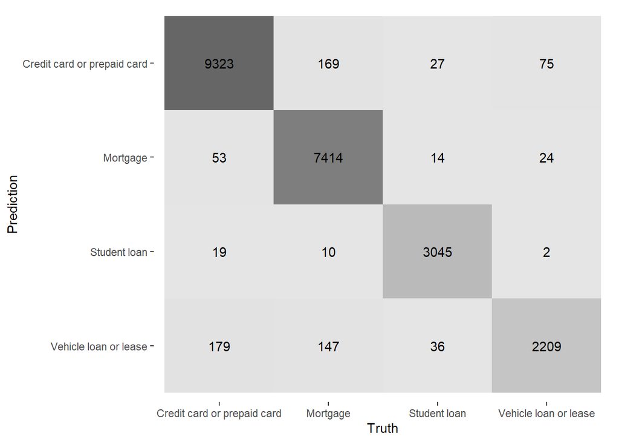

```r
# plot confusion matrix as heatmap
autoplot(confusion_matrix, type = "heatmap")
```

With an accuracy of 96.7% and ROC of 99.7% our model is performing excellently well. The estimated error rate is 3.30%

## **PLOT ROC FOR EACH OF THE PREDICTIONS**

Lets plot a ROC curve to better visualize how well our model does predicting the target classes

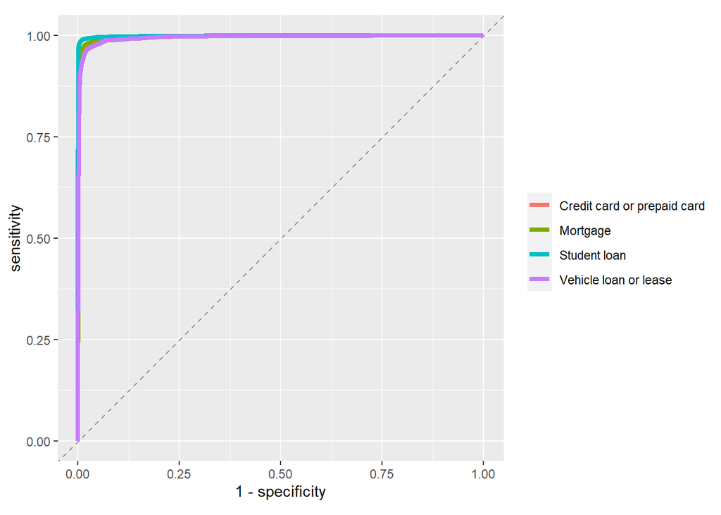

```r
collect_predictions(final_model) %>%
  roc_curve(truth = Product,
            `.pred_Credit card or prepaid card` : `.pred_Vehicle loan or lease`) %>%
  #            .pred_Mortgage:.pred_Mortgage) %>%
  ggplot(aes(1 - specificity,
             sensitivity,
             color = .level)) +
  geom_abline(slope = 1,
              color = "gray50",
              lty = 2,
              alpha = 0.8) +
  geom_path(size = 1.5,
            alhpa = 0.7) +
  labs(color = NULL) +
  coord_fixed()
```

The roc curve supports the results shown in the confusion matrix. ‘Student loan’ was the best predicted target and ‘Vehicle loan or lease’ was the worst predicted, but all came close to an auc equal to 1.

## **FIT MODEL FOR PRODUCTION**

```r
prod_fit <- extract_workflow(final_model)

prod_fit
```

```
## ══ Workflow [trained] ══════════════════════════════════════════════════════════
## Preprocessor: Recipe
## Model: multinom_reg()
##
## ── Preprocessor ────────────────────────────────────────────────────────────────
## 7 Recipe Steps
##
## • step_downsample()
## • step_tokenize()
## • step_stopwords()
## • step_stem()
## • step_tokenfilter()
## • step_tfidf()
## • step_dummy()
##
## ── Model ───────────────────────────────────────────────────────────────────────
##
## Call:  glmnet::glmnet(x = maybe_matrix(x), y = y, family = "multinomial",      alpha = ~1)
##
##       Df  %Dev   Lambda
## 1      0  0.00 0.258500
## 2      3  5.01 0.235500
## 3      3  9.28 0.214600
## 4      3 12.75 0.195500
## 5      5 16.42 0.178100
## 6      6 20.95 0.162300
## 7      7 25.16 0.147900
## 8      7 28.79 0.134800
## 9      8 32.05 0.122800
## 10     8 34.96 0.111900
## 11    11 37.91 0.101900
## 12    12 41.03 0.092880
## 13    14 43.90 0.084630
## 14    19 46.73 0.077110
## 15    21 49.64 0.070260
## 16    22 52.31 0.064020
## 17    25 54.85 0.058330
## 18    25 57.26 0.053150
## 19    29 59.52 0.048430
## 20    31 61.61 0.044130
```

[output cut: 14 more lines]

```
## 35   127 82.20 0.010930
## 36   136 83.05 0.009960
## 37   147 83.85 0.009075
## 38   159 84.60 0.008269
## 39   177 85.30 0.007534
## 40   194 85.96 0.006865
## 41   208 86.57 0.006255
## 42   228 87.16 0.005699
## 43   272 87.73 0.005193
## 44   316 88.28 0.004732
## 45   368 88.81 0.004311
## 46   436 89.32 0.003928
##
## ...
## and 54 more lines.
```

## **A LOOK AT OUR TEST DATA**

Now we make predictions with our model on unseen data. But first we have to ensure that our test data is in the right format or is compatible with our model

```r
glimpse(test_data)
```

```
## Rows: 20
## Columns: 6
## $ problem_id                   <int> 1, 2, 3, 4, 5, 6, 7, 8, 9, 10, 11, 12, 13…
## $ Consumer.complaint.narrative <chr> "I have multiple lateness/missed payments…
## $ Company                      <chr> "ECMC Group, Inc.", "Michael Wayne Invest…
## $ State                        <chr> "NY", "VA", "AR", "PA", "IN", "TX", "AZ",…
## $ ZIP.code                     <chr> "112XX", "234XX", "727XX", "189XX", "471X…
## $ Submitted.via                <chr> "Web", "Web", "Web", "Web", "Web", "Web",…
```

```r
colnames(test_data)
```

```
## [1] "problem_id"                   "Consumer.complaint.narrative"
## [3] "Company"                      "State"
## [5] "ZIP.code"                     "Submitted.via"
```

There are inconsistencies with the variable names so we have to correct that

```r
test_data <- test_data %>% rename("Consumer complaint narrative" = "Consumer.complaint.narrative",
                                  "ZIP code" = "ZIP.code", "Submitted via" = "Submitted.via")
```

## **MAKE PREDICTION WITH TEST DATA**

```r
#Get the class label predictions
class_pred <- predict(prod_fit, test_data)

#Get the probability predictions
prob_pred <- predict(prod_fit, test_data, type="prob")

#Combined into tibble and rename
predictions <- data.frame(class_pred, prob_pred) %>%
  setNames(c("Class", "Credit_Card_pred", "Mortgage_pred",
             "Student_loan_pred", "Vehicle_loan_pred"))

predictions
```

```
##                          Class Credit_Card_pred Mortgage_pred Student_loan_pred
## 1                 Student loan     1.382962e-03   0.024941427      0.8760067568
## 2        Vehicle loan or lease     4.336594e-02   0.074516465      0.0185015509
## 3                 Student loan     9.781032e-04   0.004851234      0.9889497863
## 4                     Mortgage     3.143385e-04   0.999331803      0.0001121213
## 5        Vehicle loan or lease     2.058232e-02   0.041307309      0.0163032783
## 6  Credit card or prepaid card     9.901088e-01   0.007026492      0.0008998520
## 7  Credit card or prepaid card     9.914651e-01   0.005897236      0.0007084781
## 8  Credit card or prepaid card     9.946965e-01   0.001623722      0.0007607698
## 9                 Student loan     2.017795e-02   0.057652135      0.8644686901
## 10       Vehicle loan or lease     5.931651e-02   0.046163368      0.0259246819
## 11                Student loan     8.257545e-05   0.005637943      0.9938126329
## 12                    Mortgage     2.232073e-03   0.981899034      0.0054476360
## 13 Credit card or prepaid card     3.825502e-01   0.223183121      0.0779674197
## 14 Credit card or prepaid card     9.062825e-01   0.004432553      0.0012045455
```

[output cut: 27 more lines]